# DWEI5_Aula01_ConceitosIniciais

Instituto Federal de São Paulo (IFSP)  
[Campus Bragança Paulista/SP](https://bra.ifsp.edu.br)  
**Análise e Desenvolvimento de Sistemas (ADS)**  
**5o. módulo**  
**Profa. Ana Paula Müller Giancoli**  
paulagiancoli@ifsp.edu.br

## AULA 01 - CONCEITOS INICIAIS

### Agenda

- O que é NodeJS
- O que é JSX
- O que é ReactJS
- O que é NextJS
- O que é MongoDB
- O que é GraphQL
- O que é AWS Amplify
- O que é AWS AppSync
- O que é Amplify Auth
- O que é Amazon Cognito
- O que é DynamoDB
- Perguntas

### 1. O que é NodeJS?

[figure not shown]

##### *Texto extraído de [Introduction to NodeJS](https://nodejs.dev/learn)*.

- De acordo com [NodeJS](https://nodejs.dev/learn) é ambiente de tempo de execução JavaScript de código aberto e plataforma cruzada.
- O [NodeJS](https://nodejs.org/en/) executa o mecanismo V8 JavaScript, o núcleo do Google Chrome, fora do navegador. Isso permite que o NodeJS tenha um ótimo desempenho.
- O NodeJS tem uma vantagem única porque milhões de desenvolvedores de front-end que escrevem JavaScript para o navegador agora são capazes de escrever o código do lado do servidor além do código do lado do cliente, sem a necessidade de aprender uma linguagem completamente diferente.
- Um **aplicativo NodeJS** é executado em um **único processo**, sem criar um novo thread para cada solicitação.
- Quando o NodeJS executa uma operação de entrada e saída (I/O), como ler da rede, acessar um banco de dados ou o sistema de arquivos, em vez de bloquear o thread e desperdiçar a espera dos ciclos de CPU, o NodeJS retomará as operações quando a resposta voltar. Isso permite que o NodeJS lide com milhares de conexões simultâneas com um único servidor sem introduzir o fardo de gerenciar a simultaneidade de threads, que pode ser uma fonte significativa de bugs.
- **NodeJS** é uma plataforma de baixo nível. Para tornar as coisas mais fáceis e empolgantes para os desenvolvedores, milhares de bibliotecas foram construídas em NodeJS pela comunidade, tal como: [Expresso](https://expressjs.com/), [Meteor](https://www.meteor.com/), [NextJS](https://nextjs.org/), [Strapi](https://strapi.io/) etc.

### 2. O que é JSX ?

[figure not shown]

##### Para conhecer um pouco mais de **JSX**, consulte [Introduzindo JSX](https://pt-br.reactjs.org/docs/introducing-jsx.html).

- De acordo com [Treinaweb](https://www.treinaweb.com.br/blog/o-que-e-jsx), **JSX** significa Javascript XML, e é uma forma de criar elementos para serem utilizadas como templates de aplicações React.
- Basicamente, os elementos criados com o JSX são bem similares com código HTML e fornecem aos desenvolvedores uma forma mais simples e intuitiva de criar os componentes de uma aplicação. Porém, apesar de muito similar ao HTML, o **JSX não é interpretado pelo navegador**. Por este motivo, deve-se utilizar um “transpilador” para essa conversão. Atualmente, o mais conhecido deles é o **Babel**.
- O **JSX** foi criado pela equipe de desenvolvimento do React.
- Exemplo:

```
const element = <h1>Hello, world!</h1>;
```

### 2.1. E o que é Babel?

##### *Texto extraído de [Como funciona a transpilação de código Babel por Castiglioni, Matheus](https://imasters.com.br/front-end/como-funciona-a-transpilacao-de-codigo-do-babel)* .

- Segundo [Imasters](https://imasters.com.br/front-end/como-funciona-a-transpilacao-de-codigo-do-babel), **Babel** é um compilador JavaScript, ou seja, com ele a gente consegue converter códigos modernos do JavaScript para códigos mais antigos, esse processo de ler um código novo e converter para velho é chamado de **transpilação**, ou seja, **ele vai transpilar nosso código novo para um antigo**. Dessa maneira, conseguimos escrever nossos códigos fontes em versões mais novas e "transpilar" para os antigos.
- Exemplo:
  - Uso de String Template do Javascript, e também função anônima.

```
const ola = nome => `Olá, ${nome}`
```

- Ao utilizar Babel para "transpilar" este código, ficaria assim:

```
"use strict";

var ola = function ola(nome) {
  return "Ol\xE1, ".concat(nome);
};
```

### 3. O que é ReactJS ?

[figure not shown]

##### *Texto extraído de [React - Uma biblioteca Javascript para criar interfaces de usuário](https://pt-br.reactjs.org/)*.

- De acordo com [ReactJS](https://pt-br.reactjs.org/) é uma biblioteca JavaScript para criar interfaces de usuário.
- Possibilita a criação de **Interfaces de Usuários (UI)** interativas de uma maneira fácil.
- É baseado em **componentes**. O *React* renderizará eficientemente, somente os componentes necessários à medida que sofrem modificações.
- É possível a **manipulação do Document Object Model (DOM)** -- segundo [Tableless](https://tableless.com.br/entendendo-o-dom-document-object-model/) é uma interface que representa como os documentos HTML e XML são lidos pelo seu navegador. Após o navegador ler seu documento HTML, ele cria um objeto que faz uma representação estruturada do seu documento e define meios de como essa estrutura pode ser acessada. Podemos acessar e manipular o DOM com JavaScript, sendo a forma mais fácil e usada.
- É renderizado no servidor, por meio do [NodeJs](https://nodejs.org/en/), e pode ser utilizado o [React Native](https://reactnative.dev/) para criação de aplicações *mobile*.
- Muito utilizado para construção de projetos **Single Page Applications (SPA)'s** -- de acordo com [Treinaweb](https://www.treinaweb.com.br/blog/o-que-sao-aplicacoes-spa) são conhecidos por ter apenas uma página principal e todas as outras serem escritas e modificadas pelo *JavaScript*.
- **SPA** são aplicações cuja funcionalidade está concentrada em uma única página. Ao invés de recarregar toda a página ou redirecionar o usuário para uma página nova, apenas o conteúdo principal é atualizado de forma assíncrona, mantendo toda a estrutura da página estática.
- Assim, o backend ao invés de retornar o próprio HTML formatado, retorna os dados no *formato [JSON](https://www.json.org/json-en.html)*. Essas são as nossas famosas **Application Programming Interface (API)'s**.
- Para [RedHat](https://www.redhat.com/pt-br/topics/api/what-are-application-programming-interfaces), **API** é um conjunto de definições e protocolos usado no desenvolvimento e na integração de software de aplicações. API é um acrônimo em inglês que significa interface de programação de aplicações.
- Se quiser utilizar o React no Chrome, baixe a extensão: [React DevTools for Chrome](https://chrome.google.com/webstore/detail/react-developer-tools/fmkadmapgofadopljbjfkapdkoienihi).
- Quer começar a entender? Leia o artigo [React Tutorial: An Overview and Walkthrough por Rascia, Tania](https://www.taniarascia.com/getting-started-with-react/).

### 4. O que é NextJS ?

[figure not shown]

- De acordo com [Alura](https://www.alura.com.br/artigos/next-js-vantagens), com o tempo os desenvolvedores perceberam que deixar muito código do lado do cliente (navegador) era um problema, então pensaram em uma alternativa para renderizar os códigos do lado do servidor.
- Assim, surgiu o **NextJS**, um framework criado com base no ReactJS, utilizando a renderização do lado do servidor, mais conhecido como **Server Side rendering (SSR)**.
- Além da possibilidade de melhoria da performance, o **SSR** ajuda a lidar com alguns problemas de SEO (como indexação), já que parte da aplicação ainda é carregada pelo servidor.
- O **NextJS** também permite a geração de sites estáticos, conhecido como **Static Site Generation (SSG)**. São sites sem muita interação com o usuário, com quase nenhuma mudança de interface, como exemplo: uma página com um cardápio, com fotos e preços.
- Uma outra vantagem do **NextJS** é facilidade de configuração, import dinâmico (criação de rotas), otimização de imagens, utilização do **CSS in JS** (aproveitam métodos atuais de componentização em JavaScript para criar componentes performáticos a prova de colisão, sendo esse processo extremamente automatizado) -- [Tailwind CSS](https://github.com/vercel/next.js/tree/canary/examples/with-tailwindcss), [Styled Components](https://styled-components.com/).
- Faz parte do ecossistema da [Vercel](https://vercel.com/new), que além do framework, facilitou o processo de build e deploy da aplicação.

### 4.1. E como funciona o SSR?

[figure not shown]

- Ao acessarmos um site por exemplo **bra.ifsp.edu.br**, é enviado uma requisição para o servidor para acessar a página inicial do site.
- O Servidor envia uma requisição para uma **REST API** por exemplo pedindo essa página inicial.
- Uma vez que os dados são recebidos, o servidor renderiza uma página HTML com o conteúdo e envia para o cliente exibindo assim o conteúdo na página.
- Se a pessoa acessar outra rota por exemplo **bra.ifsp.edu.br/servidores** o processo continua o mesmo.

### 4.2. E o que é REST API?

- Segundo [RedHat](https://www.redhat.com/pt-br/topics/api/what-is-a-rest-api), é conhecida como **API RESTful**, que é uma interface de programação de aplicaçãoes -- API ou API web -- que está em conformidade com as restrições de estilo de arquitetura REST, permitindo a interação com os serviços web REST.
- **REST** é a transferência representacional de estado. Não é um protocolo ou padrão, mas sim um conjunto de restrições de arquitetura.
- A **API** é um conjunto de definições e protocolos usado no desenvolvimento e na integração de aplicações.
- Em outras palavras, ao interagir com um computador ou sistema para recuperar informações ou executar uma função, a API ajudará a comunicar o que você quer ao sistema para que ele entenda e realize o que foi solicitado.

### 4.3. E como funciona a API RESTful?

- Ainda segundo [RedHat](https://www.redhat.com/pt-br/topics/api/what-is-a-rest-api): quando um cliente faz uma solicitação usando uma **API RESTful**, essa API transfere uma representação do estado do recurso ao solicitante ou endpoint.
- Essa informação (ou representação) é entregue via HTTP utilizando um dos vários formatos possíveis: Javascript Object Notation (JSON), HTML, XLT, Python, PHP ou texto sem formatação.
- O **formato JSON** é a linguagem de programação mais usada porque, apesar de seu nome, é independente de qualquer outra linguagem e pode ser lido por máquinas e humanos.

### 4.4. E o que é JSON?

[figure not shown]

##### *Texto extraído de [Afinal, o que é JSON e para que ele serve? por Souza, Ivan](https://rockcontent.com/br/blog/json/)*

- De acordo com [Rockcontent](https://rockcontent.com/br/blog/json/), **JSON**, significa **JavaScript Object Notation**, é uma formatação utilizada para estruturar dados em formato de texto e transmiti-los de um sistema para outro, como em aplicações cliente-servidor ou em aplicativos móveis.
- O **formato JSON** é utilizado para estruturar dados em formato de texto e permitir a troca de dados entre aplicações de forma simples, leve e rápida.
- Uma maneira de utilização é por meio de requisições AJAX, em que a aplicação recupera os dados armazenados no servidor de hospedagem sem a necessidade de recarregar a página.

### 5. O que é MongoDB ?

[figure not shown]

- De acordo com [MongoDB](https://www.mongodb.com/pt-br) é um banco de dados para aplicativos modernos.
- MongoDB é um banco de dados de propósito geral, baseado em **documentos** -- o que significa que ele armazena dados em documentos do **tipo JSON** e ao contrário de bancos de dados de **modelo relacional**, onde trabalhamos com registros em linhas e colunas, distribuído criado para desenvolvedores de aplicativos modernos e para a nuvem desta era.
- Leia mais sobre [O que é MongoDB? por Guedes, Maylene](https://www.treinaweb.com.br/blog/o-que-e-mongodb).

### 6. O que é GraphQL ?

[figure not shown]

- De acordo com [GraphQL](https://graphql.org/) é uma linguagem de consulta para sua API.
- O **GraphQL** foi desenvolvido pelo Facebook, que foi o primeiro a usá-lo para aplicações mobile em 2012. A especificação do GraphQL foi transformada em open source em 2015. Agora, ela é supervisionada pela GraphQL Foundation.
- O **GraphQL** foi desenvolvido para tornar as APIs mais rápidas, flexíveis e intuitivas para os desenvolvedores.
- Como alternativa à arquitetura **REST**, o **GraphQL** permite aos desenvolvedores construir solicitações que extraem os dados de várias fontes em uma única chamada de API.
- São coleções de dados (documentos). Ao compararmos com os BD relacionais, digamos que as coleções seriam as tabelas, e os resultados das queries, os registros do banco de dados relacional.
- Exemplo:

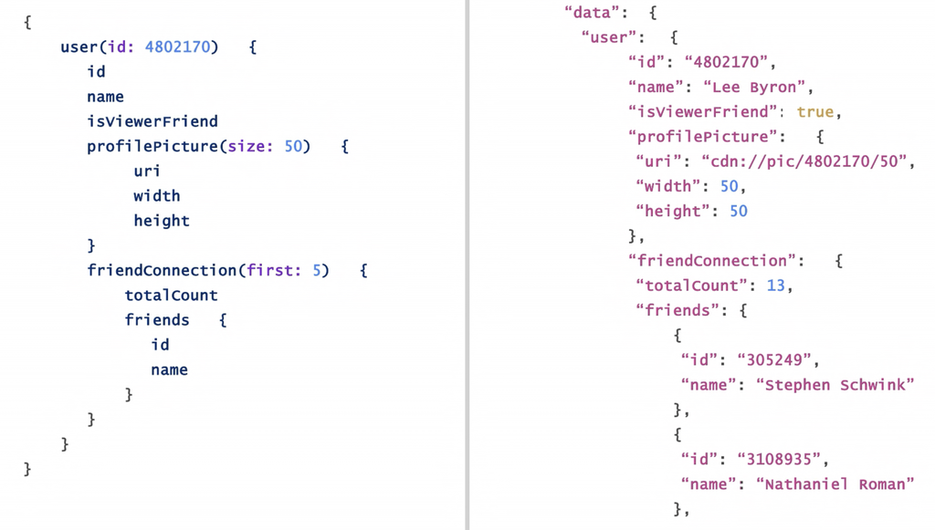

- Segundo [AWS Amazon](https://aws.amazon.com/pt/graphql/), **GraphQL** é uma linguagem para APIs que permite consultar e manipular dados facilmente por meio de uma sintaxe intuitiva e flexível.
- **GraphQL** fornece uma sintaxe para descrever os requisitos de dados e interações, permitindo que você pergunte exatamente o que você precisa e receba resultados previsíveis. Também possibilita o acesso a várias fontes em uma única solicitação, reduzindo o número de chamadas de rede e os requisitos de largura de banda, economizando bateria e ciclos de CPU consumidos por seus aplicativos.
- Fazer atualizações em seus dados é simplificado com **mutações**, permitindo que você descreva como deseja que seus dados sejam alterados.
- **GraphQL** também permite que você configure rapidamente soluções em tempo real por meio de assinaturas.
- Todos esses recursos combinados, juntamente com poderosas ferramentas de desenvolvedor, tornam o GraphQL essencial para o gerenciamento de seus dados.

### 7. O que é AWS Amplify ?

[figure not shown]

[figure not shown]

- De acordo com [AWS Amazon - Amplify](https://aws.amazon.com/pt/amplify/), **AWS Amplify** é um conjunto de ferramentas e serviços que podem ser usados em conjunto ou individualmente para permitir que desenvolvedores de front-end da web e de dispositivos móveis criem aplicações seguras e escaláveis full-stack, com tecnologia desenvolvida pela AWS.

### 8. O que é AWS AppSync ?

[figure not shown]

[figure not shown]

- De acordo com [AWS Amazon - AppSync](https://aws.amazon.com/pt/appsync/), **AWS AppSync** é um serviço totalmente gerenciado que facilita o desenvolvimento de APIs GraphQL ao lidar com o trabalho pesado de se conectar com segurança a fontes de dados como o AWS DynamoDB, Lambda e muito mais.
- As **APIs GraphQL** criadas com o **AWS AppSync** fornecem aos desenvolvedores de front-end a capacidade de consultar vários bancos de dados, microsserviços e APIs a partir de um único endpoint do GraphQL.

[figure not shown]

### 9. O que é Amplify Auth ?

- De acordo com [ReactJS](https://pt-br.reactjs.org/), **Amplify Auth** permite que você configure rapidamente fluxos de autenticação segura com um diretório de usuário totalmente gerenciado.
- Controle o que os usuários têm acesso em seus aplicativos móveis e da web com os recursos de autorização integrados do **Amplify Auth**.
- Opções clicáveis ou use comandos guiados para configurar e-mail e inscrição / login social, senha esquecida e fluxos de trabalho de autenticação multifator.

### 10. O que é Amazon Cognito ?

[figure not shown]

[figure not shown]

- De acordo com [AWS Amazon - Cognito](https://aws.amazon.com/pt/cognito/), **Amazon Cognito** permite adicionar cadastramento, login e controle de acesso de usuários a aplicações Web e móveis com rapidez e facilidade.
- O **Amazon Cognito** pode ser escalado para milhões de usuários e oferece suporte a login com provedores de identidade social como Apple, Facebook, Google e Amazon e com provedores de identidade empresariais via SAML 2.0 e OpenID Connect.

### 11. O que é DynamoDB ?

[figure not shown]

[figure not shown]

- De acordo com [AWS Amazon - DynamoDB](https://aws.amazon.com/pt/dynamodb/) é um banco de dados de valores-chave e documentos que oferece desempenho em milissegundos de um dígito em qualquer escala.
- É um **banco de dados totalmente gerenciado, multirregional, multiativo e durável com segurança, backup e restauração integrados e armazenamento em cache na memória para aplicativos em escala de Internet**.
- O **DynamoDB** pode processar mais de 10 trilhões de solicitações por dia e comportar picos de mais de 20 milhões de solicitações por segundo.

### Referências

- Esta aula foi elaborada a partir do conteúdo disponibilizado em cada um dos links indicados no próprio texto.

### Perguntas

- Esclareça suas eventuais dúvidas durante as aulas.
- Ou pelo *E-mail*: paulagiancoli@ifsp.edu.br.
- Ou acesse [Github Ana Giancoli](https://anagiancoli.github.io) e solicite atendimento para o componente curricular.

*ADS - HTML5, CSS3, JS, ReactJS, AWS - 5o. módulo*.  
Modelo e formato elaborado por profa. Ana Paula Müller Giancoli - BSD 2-Clause License. - Julho.2021.